# Unit 5. Further topics

UAB, 16-18 June, 2021

## Regression Discontinuity Design (RDD)

- Regression discontinuity designs exploit that some rules are quite arbitrary and therefore provide good **quasi-experiments**
- Treatmen assignment depends on whether a continuous variable (\(Z\)) exceeds a threshold.
  - All are treated (“sharp”)
  - Discontinuous increase in the probability of being treated (“fuzzy”)
- Threshold created by administrative rules: age (in pension), income (in social assistance), grades (in scholarships or school admission), company size (in subsidies), etc.
- Other thresholds: elections, geographical boundaries, etc.

## Example of Linear Sharp RDD

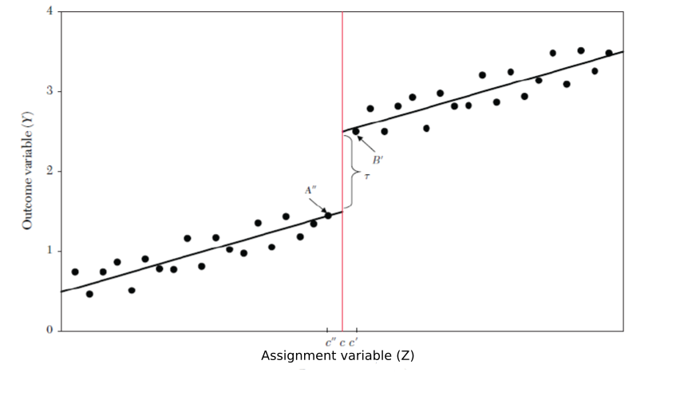

## RDD: intuition and asssumption

- Near threshold, individuals are similar: only randomness determines treatment
  - need to choose a window around the threshold
- Key assumptions:
  - no other discontinuities exist
  - no manipulation of the situation around the threshold
- Indirect evidence on assumptions:
  - similar characteristics around the threshold
  - no jumps in the distribution of Z
  - no jumps in other variables (placebo)
  - no effects at non-discontinuity points (placebo)

## Fuzzy RDD

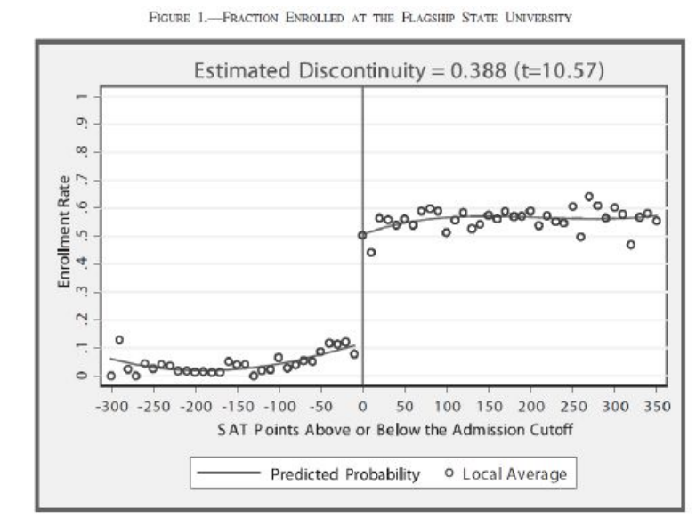

- Hoekstra (2009): The Effect of Attending the Flagship State University on Earnings: A Discontinuity-Based Approach, Review of Economics and Statistics 91(4): 717–724

## Fuzzy RDD = IV

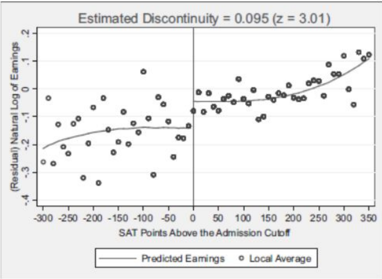

- Earnings increase approx. 9.5% at threshold; enrollment jumps by 38.8 pp → RD estimate 0.095/0.388 = 0.245

## Introduction to Machine Learning methods

> “…[M]achine learning is a field that develops algorithms designed to be applied to datasets, with the main areas of focus being prediction (regression), classification, and clustering or grouping tasks.”

> Athey (2018)
- Different subfields in ML: supervised, unsupervised learning, etc
- **Supervised Learning**: \(\small Y=f(\boldsymbol{X})+\epsilon\)
  - **Training set** (“in-sample”): \(\{(x_i,y_i)\}_{i=1}^{n}\)
  - **Test set** (“out-of-sample”): \(\{(x_i,y_i)\}_{i=n+1}^{m}\)
- **Goal**: Use a labelled training set ( \(X\) and \(Y\) are known) to construct \(\hat{f}(X)\) such that it *generalizes* to unseen test set (only \(X\) is known).

## Prediction Accuracy

- What do we mean by “good prediction”?
- A **loss function** \(L\) measures the “cost” of prediction error, i.e., in terms of
  - the “true” \(y^0\) in a single realization \((x^0,y^0)\) from the (unseen) test set
  - the prediction \(\hat{y}^0=\hat{f}(x^0)\), where \(\hat{f}\) is estimated using the *training* set.
- Examples
  - squared error (SE): \(L(\hat{y}^0, y^0)=(y^0-\hat{f}(x^0))^2\)
  - absolute error (AE): \(L(\hat{y}^0, y^0)=|y^0-\hat{f}(x^0)|\)
- Other possible forms of loss function, for instance, in terms of economic costs
- Loss functions are also different in classification problems (e.g., the probability of misclassifying a case)

## Overfitting

- The analysis corresponds too closely to a particular set of data, and, therefore may fail to fit additional data reliably
- A simpler model could have lower prediction error with new cases

[figure not shown]

## Regularization

- **Regularization** is the act of penalizing models for their complexity level.

> Regularization typically results in simpler and more accurate (though “wrong”) models.
- How to Penalize Overfit if the test set MSE is *unobservable*? Use *less* data!
- Key point: fit the model to a subset of the training set, and **validate** the model using the subset that was *not* used to fit the model.
- Adjusted R2, AIC, BIC indirectly take into account the overfitting due to the complexity of the model (i.e., adding too many covariates).

## Validation

- Split the sample to three folds: a training set, a validation set and a test set:

[figure not shown]

- CONCERNS:
  1. sensitive to the choice of training and validation set
  2. not use all of the available information.
- (k-fold) **Cross-validation**: split the training set into \(k\) roughly equal-sized parts:

[figure not shown]

- \(\small \text{CV-MSE} = \frac{1}{k}\sum_{j=1}^{k}\text{MSE}_j\)

## ML vs. Econometrics

- Different jargon: Training/test set vs. in-/out-sample, learn vs. estimate, etc.

| Machine Learning | Econometrics |
| --- | --- |
| prediction | causal inference |
| \(\hat{Y}\) | \(\hat{\beta}\) |
| minimize prediction error | unbiasedness, consistency, efficiency |
| — | statistical inference |
| stable environment | counterfactual analysis |
| black-box | structural |

- ”Data are profoundly dumb about causal relationships.” [**Pearl and Mackenzie, *The Book of Why***](http://bayes.cs.ucla.edu/WHY/)

## OLS and Penalized Regression

- *Penalized* (or *regularized*) sum of squares solves \[\underset{\beta_{0}, \beta}{\operatorname{min}} \sum_{i=1}^{N}\left(y_{i}-\beta_{0}-\sum_{j=1}^{p} x_{i j} \beta_{j}\right)^{2} \text { subject to }R(\beta) \leq t\] where \(R(\cdot)\) is a penalty function that measures the complexity (or **expressiveness**) of the model.
- After rewritig the regularization problem in the Lagrangian form:

\[\small \underset{\beta_{0}, \beta}{\operatorname{min}} \sum_{i=1}^{N}\left(y_{i}-\beta_{0}-\sum_{j=1}^{p} x_{i j} \beta_{j}\right)^{2}+\lambda R(\beta)\]

## OLS and Penalized Regression (cont’d)

| Method | Different Types of Penalty = \(R(\boldsymbol{\beta})\) |
| --- | --- |
| OLS | 0 |
| Subset selection | \(\lVert\boldsymbol{\beta}\rVert_0\) |
| Lasso | \(\lVert\boldsymbol{\beta}\rVert_1\) |
| Ridge | \(\lVert\boldsymbol{\beta}\rVert_2^2\) |
| Elastic Net | \(\alpha\lVert\boldsymbol{\beta}\rVert_1 + (1-\alpha)\lVert\boldsymbol{\beta}\rVert_2^2\) |

- \(\small \ell_0\)-norm: \(\small ||\boldsymbol{\beta}||_0=\sum_{j=1}^{p}\boldsymbol{1}_{\{\beta_j\neq0\}}\), i.e., # of non-zero elements in \(\small \boldsymbol{\beta}_{p\times 1}\).
- \(\small \ell_1\)-norm: \(\small ||\boldsymbol{\beta}||_1=\sum_{j=1}^{p}|\beta_j|\)
- \(\small \ell_2\)-norm: \(\small ||\boldsymbol{\beta}||_2=\left(\sum_{j=1}^{p}|\beta_j|^2\right)^{\frac{1}{2}}\), i.e., Euclidean norm.

## Shrinkage

- Both LASSO (least absolute shrinkage and selection operator) and Ridge Regression try to fit the data by minimizing SCR
- BUT coefficients close to zero are rewarded: **shrinkage penalty**.
  - Note: constant is NOT penalized
- These coefficients MUST NOT be used in causal analysis
- Advantage of LASSO: it performs model selection (zeros out coefficients)

[figure not shown]

## Tuning the hyperparameter \(\lambda\)

- Some parameters, called **hyperparameters**, cannot be learned directly during model training
- *Tuning process*: the best value is “estimated” by training many models and exploring their performance by cross-validation.
- **Note**: the tuning process is usually carried out using CV in the training sample only. The test partition is reserved to evaluate the finally chosen model.

## Modelling non-linearities

- We can use dummies to arbitrarily split the range of values in \(X\): e.g.,

\[ \small D_{1i}=\left\{\begin{array}{ll} 1 & \text{ if } lstat_i < 15\\ 0 & \text{ otherwise }, \end{array}\right.\quad D_{2i}=\left\{\begin{array}{ll} 1 & \text{ if } lstat_i > 25\\ 0 & \text{ otherwise}, \end{array}\right. \]

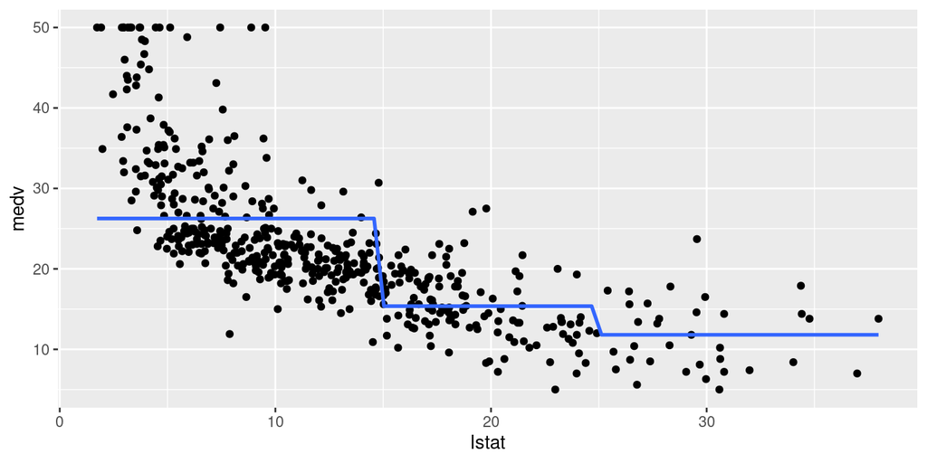

## Decission trees

- A decision tree is a flow chart with rules for segmenting the regressor space into simpler regions and classifying observations.

[figure not shown]

## Classification and regression trees (CART)

1. Split the \(X\) space into \(M\) distinct and non-overlapping regions: \(\small R_{1}, \ldots, R_{M}\)
   - Subsets are more and more homogeneous (“pure”) after each split
2. Observations in region \(R_{j}\) have the same prediction
- Going over every possible partitions of the feature space is infeasible
- Recursive binary partition algorithm (**greedy** approach):
  1. Start with the root node (one region containing the full sample)
  2. Consider each variable \(j\) and threshold \(s\) that split region into two regions
  3. Choose as the partition for this node that with minimum \(\small \mathrm{RSS}_{j,s}\)
  4. Repeat 1-3 to each child node until a leaf (final) node where a stopping criterion is met; e.g., a region with fewer than 5 observations

## Prunning trees

- Large (deep) trees contain many terminal nodes: **overfit**
- Common approach: Build one large tree \(T\) and, then, **prune** it backwards using *cost-complexity pruning*. \[\mathrm{RSS}_{cp}(T)=\mathrm{RSS}(T)+cp|T|\] where
  - \(|T|\) is the number of terminal nodes in \(T\).
  - \(cp \in [0,1]\) is the complexity parameter.
- Note that \(|T|\) is analogous to \(\lVert\boldsymbol{\beta}\rVert_1\), and \(cp\) to \(\lambda\) in the LASSO.
- \(cp\) is tuned using Cross-Validation

## Classification trees

- Splits are based on the *Gini index* (i.e., *node purity*), which is a measure of total variance across the total classes: \[G=\sum_{k=1}^{K} \hat{p}_{m k}\left(1-\hat{p}_{m k}\right)\]
- An alternative is *cross-entropy*: \[D=-\sum_{k=1}^{K} \hat{p}_{m k} \log \hat{p}_{m k}\]
- Prediction is based on a majority rule: each observation belongs to the most common class of training observations in its region.
- Variable importance is based on the decrease in the Gini index/cross-entropy

## Trees: pros and cons

- Pros:
  - Intuitive
  - Interpretable (easier to explain than regression?)
  - Nonparametric (fit complex non-linear relationships)
- Cons:
  - Overfit (small data changes, large changes in trees)
  - Worse performance (typically)

## Random forests: Basic Idea

- Instead of one single large tree, average the predictions from many smaller and noisy trees (fitted to bootstrapped re-samples)

[figure not shown]

- Also, use a subset of variables for each split (avoid correlation among trees)
- RF algorithm. For \(b=1 \ldots B\) (# bootstrapped samples = # trees in the forest):
  1. Sample with replacement \(n\) observations from training data.
  2. Grow a tree \(T_{b}\) where only a subset of \(m\) variables are (randomly) drawn in each split (\(m \approx \sqrt{p}\), dimension of \(x\) is \(p\))
  3. Typical tree model stopping criteria, but not pruning

## LASSO as a variable selection tool

- Consistency in variable selection is crucial for causal inference: remember the omitted variable bias.
- LASSO is often used as a variable selection tool in the high-dimensional part of reduced-form causal model \[Y_{i}=\alpha+\tau D_{i}+\boldsymbol{\beta}^{\prime} X_{i} + \varepsilon_{i}\] PROBLEMS:
- Coefficients are biased towards zero (shrinkage)
- Lasso might drop D or relevant confounding factors
- Choose the hyperparameter

## Solution: Double-selection Lasso

- Intuition: Partialling-out regression

**First step**: Regress \(Y_i\) on \({X}_i\) and \(D_i\) on \({X}_i\):

\[ \small \begin{aligned} \widehat{\gamma} &=\underset{\boldsymbol{\gamma} \in \mathbb{R}^{p+1}}{\arg \min } \sum_{i=1}^{n}\left(Y_{i}-\boldsymbol{\gamma}^{\prime} X_{i}\right)^{2}+\lambda_{\gamma}\left(\sum_{j=2}^{p}\left|\gamma_{j}\right|\right) \\ \widehat{\delta} &=\underset{\boldsymbol{\delta} \in \mathbb{R}^{q+1}}{\arg \min } \sum_{i=1}^{n}\left(D_{i}-\boldsymbol{\delta}^{\prime} X_{i}\right)^{2}+\lambda_{\delta}\left(\sum_{j=2}^{q}\left|\delta_{j}\right|\right) \end{aligned} \]

**Second step**: Refit the model by OLS and include the \(\mathbf{X}\)’s that are significant predictors of \(Y_i\) *and* \(D_i\).

**Third step**: Proceed to inference using standard confidence intervals.

- Tuning parameter \(\lambda\) by CV

## Extensions and Implementation

- Chernozhukov et al. (AER 2017): Other function classes (“Double-ML”), e.g., use random forest for \(Y \sim X\) and regularized logit for \(D \sim X\).
- Instrumental variables, Heterogeneous treatment effects, Panel data (several paper by Chernozhukov, Belloni and co-authors)
  - Two Python libraries [here](https://pypi.org/project/DoubleML/) and [here](https://github.com/kquist/DoubleML-Python)
  - In R, [“High-Dimensional Metrics”](https://journal.r-project.org/archive/2016/RJ-2016-040/RJ-2016-040.pdf) (`hdm` package)
  - In Stata, [`Lassopack`](https://stataLasso.github.io/docs/Lassopack/) and built-in in version 16
- Recent evidence: [Angrist and Frandsen (2019)](https://www.nber.org/papers/w26584)
  - Double-LASSO to estimate of effects of elite college attendance
  - Double lasso IV screening sometimes outperform OLS, but, standard non-ML methods (e.g., LIML) do better.

## Treatment effect heterogeneity

- It is important to identify individuals that benefit more from treatment
- Recall the conditional ATE: \(\tau(x) = \mathbb{E}[Y_{i1}-Y_{i0} | X_i = x]\)

  where \(x\) is some specific (range of) values.
- Conditional ATE can be estimated using **linear regression** (under some assumptions)

\[\small Y_i = \alpha + \tau D_i + \beta{X}_i + \gamma D_iX_i + u_i\]

- Problems:
  1. Infeasible with many variables and interaction terms
  2. LASSO might drop some main effects, so it can suffer from omitted variable bias

## Causal tree (Athey and Imbens, PNAS 2016)

- **BASIC IDEA:** use a regression tree to form a partition of the \(X\) space
- **CHALLENGES:**
  1. Conventional trees split based on \(Y_i\), but our interest is ATE= \(\tau_i\) (unobserved)
  2. How to regularize?
  3. What about confidence intervals?
- **SOLUTIONS**
  1. Split based on the treatment effect heterogeneity and accuracy
  2. Regularization also based on heterogeneity and precision of \(\tau(x)\) *within* leaves.
  3. Sample splitting: tree is built on one sample, CATE is estimated on an independent (different) sample.

## Several Approaches

- Transformed outcome trees (TOT)
- **Causal Trees**: define \(\widehat\tau_i\) as the ATE within the leaf and 2 possible splitting rules
  1. Adaptive causal tree (**CT-A**): perform a split if this *increases* treatment effect heterogeneity (variance of treatment \(\widehat\tau_i\)) within training sample.
  2. Honest causal tree (**CT-H**): perform split if it *increases* variance of treatment *and* reduces the uncertainty (“standard error”) about the estimated effect.
- Cross validation is based on the out-of-sample counterpart of the rule used for constructing the tree.
- Training sample is split into two sets:
  - training \(\mathcal{S}^{tr,tr}\) to construct the tree
  - validation \(\mathcal{S}^{tr,cv}\) to validate it

## Causal tree algorithm: summary

1. Random split of the sample in two halves: a training sample \(\mathcal{S^{tr}}\) and an estimation sample \(\small \mathcal{S^{est}}\)
2. Using only \(\small \mathcal{S^{tr}}\), grow a tree where each split is based on a criteria that maximizes:
   - how much the estimated treatment effect *varies* across the two resulting subgroups (maximize treatment heterogeneity)
   - how *accurate* these estimates are (minimize the estimated variance)
3. Using just \(\small \mathcal{S^{est}}\), compute \(\tau(x)\) within each terminal node (leaf)

## Implementation of causal trees

- The causal tree algorithm was originally implemented by Susan Athey in the R package [`{causalTree}`](https://github.com/susanathey/causalTree)
- It has been adapted to Python: https://pypi.org/project/causal-tree-learn/
- Hyperparameters:
  - `minsize`: the minimum number of treatment and control observations in each leaf.
  - `bucketNum` and `bucketMax`: guarantee that both treatment and control observations are added when we shift from one split point to the next (the estimate of the goodness of fit as a function of the split point is smooth).

## Causal forests (Wager and Athey, JASA 2018)

- An individual causal tree can be noisy (as predictive trees)
1. Draw a random subsample \(b\) of size \(m\) from the \(N\) obs. w/o replacement
2. Randomly divide \(b\) into training \(\mathcal{S^{tr}_b}\) and estimation sample \(\mathcal{S^{est}_b}\).
3. Using just \(\mathcal{S^{tr}_b}\), grow a tree via recursive partitions using criteria that maximize treatment heterogeneity and minimize estimate variance (as before)
4. Using only \(\mathcal{S^{est}_b}\), calculate \(\widehat\tau_b(x)\) within each terminal leaf.
5. In the full sample, assign each \(i\) according to the estimated tree.
6. Repeat \(B\) times steps 1-5 and compute cond. ATE for each \(i\) as \(\small B^{-1}\sum_{j=1}^{B}\widehat\tau_b\).

## Implementation of causal forests

- Originally implemented in the R package [`{grf}`](https://github.com/grf-labs/grf) package (Tibshirani, Athey, and Wager).
- Adapted to Python: https://pypi.org/project/causal-tree-learn/
- Arguments
  - number of trees.
  - subsample size.
  - minimum number of treatment and control observations in each leaf.
  - number of variables considered at each split